# FigureYa114ternaryCluster

小丫画图出品

2019-7-14

欢迎关注“小丫画图”公众号，同名知识星球等你加入

小丫微信: epigenomics E-mail: figureya@126.com

作者：大鱼海棠

单位：Research Center of Biostatistics and Computational Pharmacy, China Pharmaceutical University

贝塔猫编辑校验

## 需求描述

仅对某感兴趣通路做聚类分析，同时纳入正常样本表达水平的考虑，来挖掘癌症样本异质性。大神丢的文章能解决我的问题，想众筹下面这个图

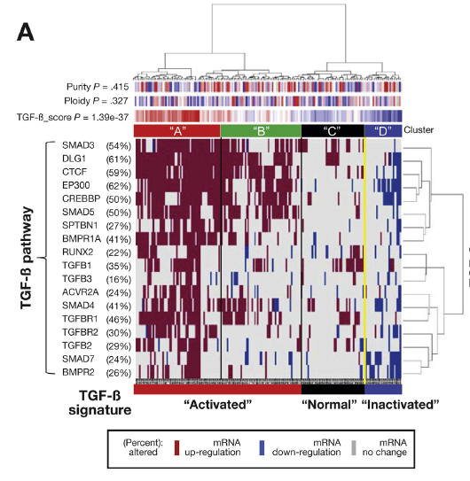

出自https://www.gastrojournal.org/article/S0016-5085(17)36144-9/abstract

## 应用场景

在一组样本中某个geneset表达谱变异很大时，展示这个geneset的所有基因表达异质性。

同时还能根据这个geneset的基因表达谱对样本进行分组。分组结果可尝试用于解释样本的另一个性状或临床指标（如预后）的差异，最终证明该geneset与样本性状或临床指标的关联。

## 环境设置

```r
#使用国内镜像安装包
options("repos"= c(CRAN="https://mirrors.tuna.tsinghua.edu.cn/CRAN/"))
options(BioC_mirror="http://mirrors.ustc.edu.cn/bioc/")

#安装并加载包
Packages <- c("pheatmap","gplots")#CRAN的包
for(pk in Packages){
  if(!require(pk,character.only = T,quietly = T)) install.packages(pk)
  suppressMessages(library(pk,character.only = T))
}
if(!require("GSVA",character.only = T,quietly = T)){
  if(!require("BiocManager",character.only = T, quietly = TRUE)) install.packages("BiocManager")
  BiocManager::install("GSVA")#Bioconductor的包
}
suppressMessages(library("GSVA",character.only = T))
Sys.setenv(LANGUAGE = "en") #显示英文报错信息
options(stringsAsFactors = FALSE) #禁止chr转成factor
```

## 参数设置

```r
tumornumber <- 147 #表达矩阵前多少列来自肿瘤样本
normalnumber <- 50 #表达矩阵后多少列来自正常样本
signaturename <- "TGFB"
# 设置基因分类阈值，用于判断基因的表达状态
halfwidth <- 0.025
# 样本分类个数
ClusterNumber <- 4
#样本类对应颜色
ClusterColor = c("#B31E22","#529B40","#020105","#383D8E")
```

## 读取输入文件

需要两个输入文件：基因表达矩阵和感兴趣的基因通路

- easy_input_expr.csv，文章作者提供的32189*197基因表达矩阵(FPKM)，前147列来自肿瘤样本，后面是50个正常对照的表达谱。
- easy_input_signatures.csv，某一通路基因列表，此处是TGFbeta。

```r
expr <- read.csv("easy_input_expr.csv",check.names = F,row.names = 1)
expr[1:3,1:3]
```

```
##        LIHC-A114-01A LIHC-A4NB-01A LIHC-A5RG-01A
## TSPAN6         41.24         28.55         59.39
## TNMD            0.03          0.00          0.02
## DPM1           17.56         21.47         28.95
```

```r
signature <- read.csv("easy_input_signatures.csv")[,1]
signature
```

```
##  [1] "SMAD3"  "SPTBN1" "SMAD4"  "SMAD5"  "SMAD7"  "TGFBR1" "TGFBR2"
##  [8] "ACVR2A" "EP300"  "CREBBP" "RUNX2"  "CTCF"   "DLG1"   "BMPR1A"
## [15] "BMPR2"  "TGFB1"  "TGFB2"  "TGFB3"
```

## 估计GSVA富集分数，后面用于检验富集分数在k个类的差异

```r
siglist <- list()
siglist[[signaturename]] <- signature
signature.gsva <- gsva(as.matrix(expr[,1:tumornumber]),siglist,method = "gsva")
```

```
## Estimating GSVA scores for 1 gene sets.
## Computing observed enrichment scores
## Estimating ECDFs with Gaussian kernels
## Using parallel with 4 cores
##
```

## 根据正常样本signature基因表达将肿瘤样本基因表达状态分成3类：高标达、低表达、不变

```r
# 提取signature基因表达矩阵，筛选样本间有差异的基因
rowids <- intersect(rownames(expr), signature)
logdata <- log2(expr[rowids, ] + 0.5)
tumordata <- logdata[, 1:tumornumber] # 输入数据仅为肿瘤样本
var <- apply(tumordata, 1, sd, na.rm=T) # 计算每个基因的标准差
selvar <- var[var>0] # 只选取在肿瘤样本间存在差异的基因
tumordata <- tumordata[names(selvar), ]
normaldata <- logdata[names(selvar), (tumornumber+1):(tumornumber+normalnumber)] # 正常样本的对应表达

# 根据文献方法提供的标准，判断各个基因相对于正常样本高表达或者低表达的状态

# 首先设置基因分类阈值，计算各个基因在正常样本中高表达或者低表达阈值
halfwidth <- 0.025
normaldown <- apply(normaldata, 1, function(x) quantile(x, probs=halfwidth, na.rm=T) )
normalup <- apply(normaldata, 1, function(x) quantile(x, probs=1-halfwidth, na.rm=T) )

# 根据判断表达状态，得到的状态矩阵用于聚类和绘图
for (k in 1:nrow(tumordata)) {
  rowk <- as.numeric(tumordata[k, ])
  out <- rep(0, times=ncol(tumordata)) # 全部分配0
  out[rowk>normalup[k]] <- 1 # 高表达分配1
  out[rowk<normaldown[k]] <- -1 # 低表达分配-1
  tumordata[k, ] <- out
}

# 输出结果，不用于绘图
outdata <- tumordata
outdata[outdata==1] <- "UP" # 高表达标记为UP
outdata[outdata==-1] <- "DOWN" # 低表达标记为DOWN
outdata[outdata==0] <- "NOCHANGE" #不变标记为NOCHANGE
write.csv(outdata,"Ternary.csv",row.names = T,col.names = NA)
```

## 聚类并绘图

```r
### 行和列使用ward.D聚类
hcg <- hclust(dist(tumordata), "ward.D")#行聚类
hcs <- hclust(dist(t(tumordata)), "ward.D")#列聚类
k <- ClusterNumber # 列聚类数目
group <- paste0("C",cutree(hcs,k))
names(group) <- colnames(tumordata)

# 注释信息
annCol <- data.frame(Cluster=group,score=signature.gsva[signaturename,])
# 检验TGFBscore在k个类的差异(非参),计算pvalue
p <- kruskal.test(annCol$score ~ as.factor(annCol$Cluster))$p.value
colnames(annCol)[2] <- paste0(signaturename,"_score P = ",format(p,digits = 3)) # 科学计数法保留2位

# 对应注释信息的颜色
annColors <- list(Cluster = c(C1 = ClusterColor[1],
                              C2 = ClusterColor[2],
                              C3 = ClusterColor[3],
                              C4 = ClusterColor[4]),
                  bluered(64))
names(annColors)[2] <- colnames(annCol)[2]

pct <- paste0(round(rowSums(tumordata == 1)/ncol(tumordata),2) * 100,"%") # 计算上调基因百分比
rownames(tumordata) <- paste0(rownames(tumordata)," (",pct,")") # 行名加上这个百分比

# 绘图
pheatmap(tumordata,
         cluster_rows = hcg,
         cluster_cols = hcs,
         color = c("#283285","#DEDEDE","#651430"),
         annotation_col = annCol,
         annotation_colors = annColors,
         fontsize_col = 2, # 行名大小
         fontsize_row = 8, # 列名大小（也可以不显示）
         fontsize = 6, # 总体大小，目的是调低图例的大小
         cutree_cols = k, # 切割图片
         legend_breaks = c(-1,0,1), # 修改图例的显示位置
         legend_labels = c("mRNA\ndown-regulation","mRNA\nno-change","mRNA\nup-regulation"), # 修改图例各位置的名称
         filename = "Heatmap_TernaryCluster.pdf",width = 7,height = 5)
```

[figure not shown]